# STSCI 4630 - Lec 07

Harry Lu

Feburary 12, 2019

**Linear Regression**

$$\underbrace{\sum_{i=1}^{n}\left(Y_i-\bar{Y}\right)^2}_{\text{SST}}=\underbrace{\sum_{i=1}^{n}\left(Y_i-\hat{Y_i}\right)^2}_{\text{SSE}}+\underbrace{\sum_{i=1}^{n}\left(\hat{Y_i}-\bar{Y}\right)^2}_{\text{SSR}}$$

$$\text{R}^2=\frac{\text{SSR}}{\text{SST}}$$

Nested Models: (partial F-test)

1. Full $K+L$ predictors
2. Reduced $K$ predictors

$\text{R}^2_{K+L}\geq\text{R}^2_K$ even if the additional $L$ predictors are irrelevant

But suppose we want to compare:

- $Y_i=\beta_0+\beta_1X_{1i}+\beta_2X_{2i}+\beta_3X_{3i}+\epsilon_i$
- $Y_i=\beta_0+\beta_1X_{1i}+\beta_2X_{4i}+\epsilon_i$

$$\text{R}^2=1-\frac{\text{SSE}}{\text{SST}}$$

$$\text{R}^2_{\text{adj}}=1-\frac{\text{SSE}/(n-p-1)}{\text{SST}/(n-1)}=1-\frac{n-1}{n-p-1}\cdot\frac{\text{SSE}}{\text{SST}}$$

where $p$ is the number of predictors

$\frac{\text{SSE}}{\text{SST}}$ decreases when $p$ increases

$\frac{n-1}{n-p-1}$ increases when $p$ increases

For general models with MLE

Idea:

Prefer models under which the probability of the observed data can be made larger

But with nested models, the maximized probability of the data will be larger for the model having more parameters

We introduce a penalty for the number of parameters in the model

Consider the likelihood function

$$\mathcal{L}(\theta;y_1,\cdots,y_n)$$

And log-likelihood function

$$l(\theta)=\ln[\mathcal{L}(\theta)]$$

Examine $\mathcal{L}\left(\hat\theta;y_1,\cdots,y_n\right)\rightarrow l\left(\hat\theta\right)=\ln\left[\mathcal{L}\left(\hat\theta\right)\right]$

Consider $-2l\left(\hat\theta\right)$

To account for the number of parameter in the model, we introduce a penalty

AIC: minimize $-2l\left(\hat\theta\right)+2p$

BIC: minimize $-2l\left(\hat\theta\right)+\ln(n)\cdot p$

where $p$ is the number of parameters

BIC gives smaller models than AIC, $\ln(n)>2$ for usual $n$

**Time Series Models**

ARMA(p,q):

$$\begin{align}
Y_t-\mu
&=
\phi_1(Y_{t-1}-\mu)+\cdots+\phi_p(Y_{t-p}-\mu)\\
&\quad+\theta_1\epsilon_{t-1}+\cdots+\theta_q\epsilon_{t-q}+\epsilon_t
\end{align}$$

Use AIC and BIC to choose between models:

$$\begin{align}
Y_t
&=
(\mu-\phi_1\mu-\phi_2\mu-\cdots-\phi_p\mu)\\
&\quad+\phi_1Y_{t-1}+\cdots+\phi_pY_{t-p}\\
&\quad+\theta_1\epsilon_{t-1}+\cdots+\theta_q\epsilon_{t-q}+\epsilon_t
\end{align}$$

ARIMA (Auto Regressive Integrated Moving Average)

ARIMA(p,d,q):

$$B\cdot Y_t=Y_{t-1}$$

where $B$ is back-shift operator

$$\begin{align}
\triangle Y_t
&=
(1-B)Y_t\\
&=
Y_t-Y_{t-1}\\
\triangle^2Y_t
&=
(1-B)^2Y_t\\
&=
(1-2B+B^2)Y_t\\
&=
Y_t-2Y_{t-1}+Y_{t-2}\\
&=
\triangle(Y_t-Y_{t-1})
\end{align}$$

Generally, $\triangle^dY_t=(1-B)^dY_t$

$Y_t$ is ARIMA(p,d,q) if $\triangle^dY_t$ is ARMA(p,q)

**Forecasting from Time Series Models**

Example: AR(1) Model

Observe $Y_1,\cdots,Y_n$

Model:

$$\begin{align}Y_t&=\mu+\phi(Y_{t-1}-\mu)+\epsilon_t\\&=\mu(1-\phi)+\phi Y_{t-1}+\epsilon_t\end{align}$$

Get estimates $\hat\mu$, $\hat\phi$ by MLE, say

$$Y_t=\hat\mu+\hat\phi(Y_{t-1}-\hat\mu)+\epsilon_t$$

Then

$$\begin{align}
\widehat{Y_{n+1}}&=\hat\mu+\hat\phi(Y_n-\hat\mu)\\
\widehat{Y_{n+2}}&=\hat\mu+\hat\phi(\widehat{Y_{n+1}}-\hat\mu)
\end{align}$$

**Portfolio Selection**

Available assets $A_1,\cdots,A_N$

Create a portfolio, we put weights on the assets: $A_i$ gets weight $w_i$ where $\sum_{i=1}^{N}w_i=1$

Let $R_i$ be the net return on asset $A_i$

If $A_i$ is a safe asset, then $A_i$ has $\sigma_i=0$

Suppose $R_i$ has mean $\mu_i$ and standard deviation $\sigma_i$, the portfolio net return is $R_p=w_1\cdot R_1+\cdots+w_N\cdot R_N$

$\mu_p=\text{E}(R_p)$ and $\sigma_p=\text{SD}(R_p)$

Goals:

1. Maximize expected return $\mu_p$
2. Minimize risk $\sigma_p$

Special case: $N=2$, $\sigma_2=0$, $\sigma_1>0$ perhaps (one risky asset, one safe asset)

Put $\mu_2=\mu_f$ where $\mu_f$ is risk-free rate

$R_p=w_1\cdot R_1+w_2\cdot R_2=w\cdot R_1+(1-w)\cdot R_2$ where $w=w_1$ and $1-w=w_2$

$$\begin{align}
\mu_p&=w\cdot\mu_1+(1-w)\cdot\mu_f\\
&=\mu_f+w\cdot(\mu_1-\mu_f)
\end{align}$$

where $\mu_1-\mu_f$ is called the excess return

$$\begin{align}
\sigma_p^2&=w^2\cdot\sigma_1^2+(1-w)^2\cdot\sigma_2^2\\
&=w^2\cdot\sigma_1^2
\end{align}$$

so $\sigma_p=|w|\cdot\sigma_1$

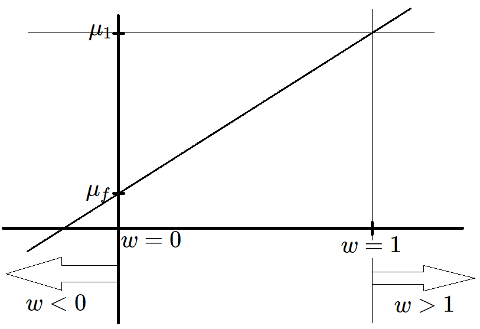

In the $w<0$ region: sell asset $A_1$ short, use revenue to buy risk-free asset

In the $w>1$ region: borrow money at rate $\mu_f$, use that income to buy the risky asset

Thanks to *Zhenjie Shen* for help with the notes.